# Covid-19 Cases in Bosnia and Herzegovina

A.G.J Thenura(AS2019554)

10/7/2022

## **1. Introduction**

The COVID-19 pandemic is an ongoing global pandemic of coronavirus disease 2019 caused by severe acute respiratory syndrome coronavirus. The World Health Organization (WHO) declared the outbreak a public health emergency of international concern on 30 January 2020 and a pandemic on 11 March 2020. The pandemic had caused more than 618 million cases and 6.54 million confirmed deaths, making it one of the deadliest in history.

#### **1.1 About Bosnia and Herzegovina**

The COVID-19 pandemic and its economic consequences have had a relatively high impact on Bosnia and Herzegovina’s population and economy. The authorities acted quickly to contain the virus during the first wave of the pandemic and Bosnia has experienced several waves of the pandemic.The first case of COVID-19 was reported on 5 March 2020 and the first death on 21 March. In Bosnia and Herzegovina, from 3 January 2020 to, 6 October 2022, there have been 398,796 confirmed cases of COVID-19 with 16,138 deaths, reported to WHO. As of 28 January 2022, a total of 1,924,950 vaccine doses have been administered.

[interactive chart not shown]

*Figure 01* : Bosnia and Herzegovina in World Map

#### **1.2 Location and population**

Bosnia and Herzegovina is thus the 26th smallest country in Europe and ranked 129th in the world. Only slightly Less than half of all residents (49%) live within cities. This country situated in the western Balkan Peninsula of Europe. The larger region of Bosnia occupies the northern and central parts of the country, and Herzegovina occupies the south and southwest. Bosnia and Herzegovina borders Serbia to the east, Montenegro to the southeast, and Croatia to the north and southwest.The capital of the country is Sarajevo. The land has a total area of 51,210 km² (19,772 mi²) and a total coastline of 20 km.The country has 3 islands in the open sea. There are direct national borders with the 3 neighbouring countries Croatia, Montenegro and Serbia. The distance between New York City and the Capital Sarajevo is about 7,190 km. The current population of Bosnia and Herzegovina is 3,234,781 and it is density in Bosnia and Herzegovina is 64 per Km2.

#### **1.3 Climate**

A moderate climatic zone determines the weather in Bosnia and Herzegovina.Depending on the season, the average daytime temperatures range between 6 and 30 degrees. Bosnia and Herzegovina has been hit by a number of devastating floods in recent years, including the worst flooding in recorded history that swept through the country in May. On 22 June, heavy rainfalls have caused rivers and creeks in North-eastern part of Bosnia and Herzegovina to swell and flood houses and roads along their banks, forcing many to fear for their lives and properties.

Authorities in Bosnia and Herzegovina acted quickly to contain the spread of the virus, yet future health resilience is not guaranteed. A state of emergency was declared in late March. A lockdown was implemented, and citizen movements were restricted. The borders, public areas, parks and shopping malls were closed; grocery stores and pharmacies remained open. The restrictive measures were effective and led to reduced movements throughout Bosnia and Herzegovina with respect to February.

### **2. Exploratory Data Analysis**

#### **2.1 Structure of Data**

The data set used for this analysis is The 2019 Novel Coronavirus COVID-19 (2019-nCoV) Dataset which is easily available as an installable package in RStudio. The source of this data is Johns Hopkins University Center for Systems Science and Engineering (JHU CCSE) Coronavirus.

The dataset contains the daily summary of Coronavirus cases worldwide. All cases are recorded according to the following variables;

- date: Date in YYYY-MM-DD format.
- province: Name of province/state, for countries where data is provided split across multiple provinces/states.
- country: Name of country/region.
- lat: Latitude of center of geographic region, defined as either country or, if available, province.
- long: Longitude of center of geographic region, defined as either country or, if available, province.
- type: An indicator for the type of cases (confirmed, death, recovered).
- cases: Number of cases on given date.

The analysis has been done by R, a programming language for statistical computing and graphics.

#### **2.2 COVID-19 Statistics of Bosnia and Herzegovina**

The data presented below are valid only up to the date of 23rd June 2022. The current situation might be quite different from what is depicted below. Summary measures of total Confirmed cases, Death cases and Recovery cases are as follows

| type | Minimum | First_Q | Median | Mean | Third_Q | Maximum | Total |
| --- | --- | --- | --- | --- | --- | --- | --- |
| confirmed | 0 | 0 | 112 | 428.02036 | 632.5 | 5254 | 378370 |
| death | 0 | 0 | 4 | 17.93764 | 28.0 | 207 | 15821 |
| recovery | 0 | 0 | 0 | 214.84711 | 247.0 | 2542 | 189710 |

```
##       date              province           country               lat
##  Min.   :2020-01-22   Length:2649        Length:2649        Min.   :43.92
##  1st Qu.:2020-08-29   Class :character   Class :character   1st Qu.:43.92
##  Median :2021-04-07   Mode  :character   Mode  :character   Median :43.92
##  Mean   :2021-04-07                                         Mean   :43.92
##  3rd Qu.:2021-11-15                                         3rd Qu.:43.92
##  Max.   :2022-06-23                                         Max.   :43.92
##       long           type               cases             uid
##  Min.   :17.68   Length:2649        Min.   :   0.0   Min.   :70
##  1st Qu.:17.68   Class :character   1st Qu.:   0.0   1st Qu.:70
##  Median :17.68   Mode  :character   Median :  12.0   Median :70
##  Mean   :17.68                      Mean   : 220.4   Mean   :70
##  3rd Qu.:17.68                      3rd Qu.: 172.0   3rd Qu.:70
##  Max.   :17.68                      Max.   :5254.0   Max.   :70
##      iso2               iso3               code3    combined_key
##  Length:2649        Length:2649        Min.   :70   Length:2649
##  Class :character   Class :character   1st Qu.:70   Class :character
##  Mode  :character   Mode  :character   Median :70   Mode  :character
##                                        Mean   :70
##                                        3rd Qu.:70
##                                        Max.   :70
##    population      continent_name     continent_code
##  Min.   :3280815   Length:2649        Length:2649
##  1st Qu.:3280815   Class :character   Class :character
##  Median :3280815   Mode  :character   Mode  :character
##  Mean   :3280815
##  3rd Qu.:3280815
##  Max.   :3280815
```

#### **2.2 Graphical Visualization of COVID-19 cases in Bosnia and Herzegovina**

- **Daily COVID-19 cases in Bosnia and Herzegovina**

[figure not shown]

  *Figure 02* : Multiple Time Series Plot

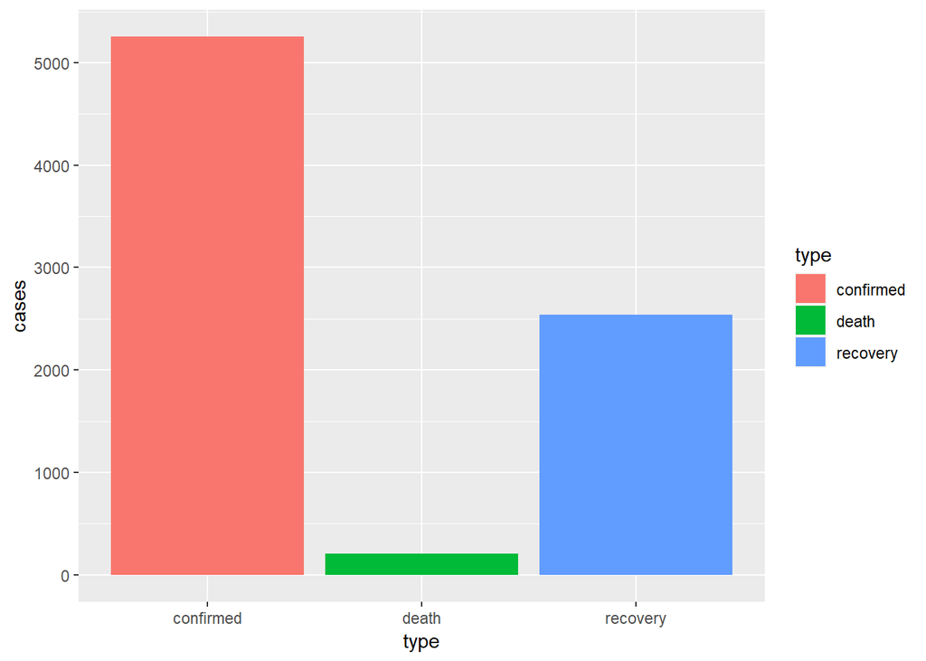

  Overall Bosnia and Herzegovina has been performing well in keeping the fatality rate very low compare to the confirmed cases.And the number of recovery cases are also considerably high.
- **Daily Active COVID-19 cases in Bosnia and Herzegovina**

[figure not shown]

  *Figure 04* : Daily Active Cases

  Above animated figure represents the daily active cases in Bosnia and Herzegovina. Daily active cases growth rate in Bosnia and Herzegovina appears a lower growth rate in 2020 when compared with 2021 & 2022.There is a considerable drop in middle of the year 2021 in daily active cases.But after that the figure clearly shows that the growth rate of daily cases were increased.

#### **2.3 Comparison of COVID-19 cases of Bosnia and Herzegovina with other Countries**

Its hard to come to an accurate image on the COVID-19 cases by only looking at the COVID-19 cases in Bosnia and Herzegovina alone.Therefore,here the COVID-19 cases of Bosnia and Herzegovina is compared with the countries Serbia,Hungary and Italy which are in the same geographical region. And also here we are comparing the effectiveness of Bosnia and Herzegovina ’s virus prevention plan with regards to China & SriLanka.

[interactive chart not shown]

*Figure 05* : Location of Compaired Countries

- **Comparison of Daily Confirmed Cases in Bosnia and Herzegovina with near by Countries**

[figure not shown]

  *Figure 06* : Multiple Time Series plot- Comparison

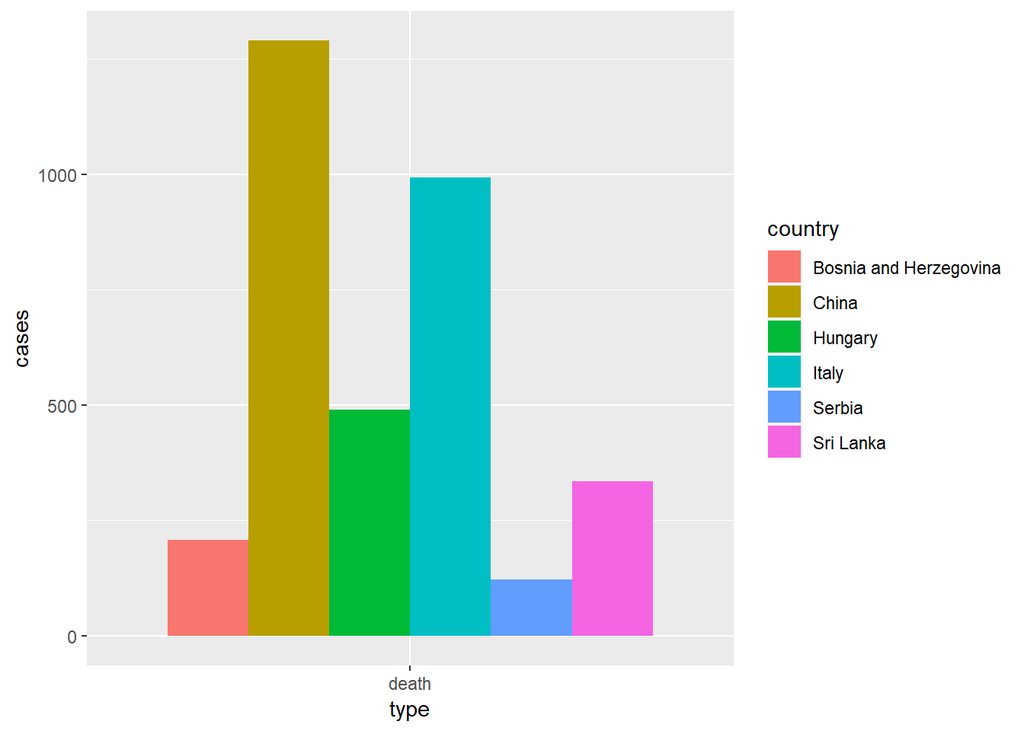

  Highest number of deaths are recorded in front of China and Serbia has the lowest number or death cases.However the number of death cases in Bosnia and Herzegovina also considerably low when compared with other countries.Above figure shows that Italy has the highest number of death cases among the countries which are in the same geographical region with Bosnia and Herzegovina.

### **4. Limitations**

When it comes to the comparison part,I have ignored NA cases and negative value cases.

### **5. References**

- https://www.oecd-ilibrary.org/sites/f0011603-en/index.html?itemId=/content/component/f0011603-en
- https://reliefweb.int/disaster/ff-2020-000153-bih
- https://www.worldometers.info/world-population/bosnia-and-herzegovina-population/
- https://www.worldbank.org/en/results/2014/11/05/weathering-the-storm-disaster-recovery-in-bosnia-and-herzegovina
- https://en.wikipedia.org/wiki/Bosnia_and_Herzegovina
- https://medium.com/@ndleah/animation-plot-with-gganimate-e34f8ae5d837
- http://www.gomapper.com/travel/list-of-countries-near/bosnia-and-herzegovina.html